# 1. Introduction

In this project, a dataset of about 82000 rows and 20 columns was given regarding the reviews of various board games available. A supervised machine learning model as then been trained and evaluated to predict the ratings given to a particular board game based on several features of the datasets.

In order to choose the machine learning algorithms best suited to make predictions of the average rating of the board games, number of regression or similar models were considered and the data has been investigated to choose the best possible models:

Considering that the problem is to predict a numerical value several options such as follows could be chosen:

### i. Linear Regression:

Can be chosen if the variables show a linear correlation with the label. If the correlation is not linear, the linear regression model would not be accurate.

### ii. Decision Trees and Random forest regression:

A Decision Tree is an intuitive model where by one traverses down the branches of the tree and selects the next branch to go down based on a decision at a node.While building the tree, the goal is to split on the attributes which create the purest child nodes possible, which would keep to a minimum the number of splits that would need to be made in order to classify all instances in our dataset. Purity is measured by the concept of information gain, which relates to how much would need to be known about a previously-unseen instance in order for it to be properly classified. Random Forests are simply an ensemble of decision trees. The input vector is run through multiple decision trees. For regression, the output value of all the trees is averaged; for classification a voting scheme is used to determine the final class. Great at learning complex, highly non-linear relationships.Very easy to interpret and understand. can be prone to major overfitting.Using larger random forest ensembles to achieve higher performance comes with the drawbacks of being slower and requiring more memory.

### iii. Neural Network regression:

A Neural Network consists of an interconnected group of nodes called neurons. The input feature variables from the data are passed to these neurons as a multi-variable linear combination, where the values multiplied by each feature variable are known as weights. A non-linearity is then applied to this linear combination which gives the neural network the ability to model complex non-linear relationships. A neural network can have multiple layers where the output of one layer is passed to the next one in the same way. At the output, there is generally no non-linearity applied. Neural Networks are trained using Stochastic Gradient Descent (SGD) and the backpropagation algorithm. They are very effective for data with complex non-linear relationships with negligible consideration to the structure of the data. However, these models could be difficult to interpret and computationally challenging.

```python
import sys
import pandas
import sklearn
import matplotlib
import seaborn

print(sys.version)
print(pandas.__version__)
print(matplotlib.__version__)
print(seaborn.__version__)
print(sklearn.__version__)
```

```
3.6.5 |Anaconda, Inc.| (default, Mar 29 2018, 13:32:41) [MSC v.1900 64 bit (AMD64)]
0.23.0
2.2.2
0.8.1
0.19.1
```

```python
import matplotlib.pyplot as plt
import seaborn as sns
from sklearn.model_selection import train_test_split
```

```python
#Loading the data
game = pandas.read_csv("games.csv")
# Observing the shape, columns and some rows of the dataframe
print(game.shape)
print(game.columns)
game.head
```

```
(81312, 20)
Index(['id', 'type', 'name', 'yearpublished', 'minplayers', 'maxplayers',
       'playingtime', 'minplaytime', 'maxplaytime', 'minage', 'users_rated',
       'average_rating', 'bayes_average_rating', 'total_owners',
       'total_traders', 'total_wanters', 'total_wishers', 'total_comments',
       'total_weights', 'average_weight'],
      dtype='object')
```

[output not shown]

[output cut: 364 more lines]

# 2. Visualizing and Exploring the data

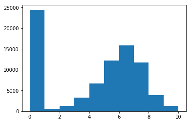

```python
plt.hist(game['average_rating'])
```

```python
# printing the 10 of the rows which has 0 average rating and also printing those which have average rating greater than 0

print(game[game["average_rating"] == 0].iloc[0:10])
print(game[game["average_rating"] > 0].iloc[0:10])
```

```
         id       type                         name  yearpublished  \
13048   318  boardgame                   Looney Leo            0.0
13068   579  boardgame                Field of Fire         2002.0
13114   894  boardgame                    LifeLinks         2000.0
13116   897  boardgame                    Dear Abby         1992.0
13124   946  boardgame                     Rolazone         1999.0
13127   962  boardgame                     Contango         2000.0
13169  1097  boardgame  Don't Give Up Your Day Job!         2000.0
13180  1151  boardgame        Money, Power, Respect         2000.0
13181  1154  boardgame                 Nuts! To You         1987.0
13188  1180  boardgame             Tower of Babylon            0.0

       minplayers  maxplayers  playingtime  minplaytime  maxplaytime  minage  \
13048         0.0         0.0          0.0          0.0          0.0     0.0
13068         2.0         0.0          0.0          0.0          0.0    12.0
```

[output cut: 103 more lines]

Thus, from observing the rows with 0 average rating it can be reasonably concluded that all the games which have 0 rating have 0 users rated. Thus, for all the games which have not been played or published or not rated the average rating showed up to be 0. Thus, these rows could be removed from the data frame. Further, if any missing values are prevalent in the dataframe, those rows must also be removed.

```python
# Finding the number of missing values in each column
game.isnull().sum()
```

```
id                       0
type                     0
name                    41
yearpublished            3
minplayers               3
maxplayers               3
playingtime              3
minplaytime              3
maxplaytime              3
minage                   3
users_rated              0
average_rating           0
bayes_average_rating     0
total_owners             0
total_traders            0
total_wanters            0
total_wishers            0
total_comments           0
total_weights            0
average_weight           0
dtype: int64
```

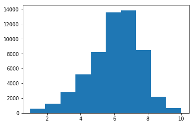

```python
# Removing the rows with missing values
game = game.dropna(axis = 0)

# Removing rows with 0 user reviews
game = game[game["users_rated"] > 0]

#Plotting the histogram again
plt.hist(game["average_rating"])
```

In order to know if there are any strong correlations prevalent in the dataset, correlation matrix has been plotted as follows

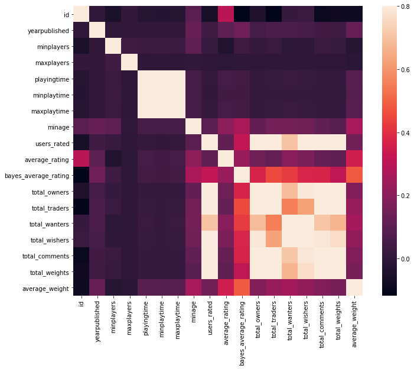

```python
#  Correlation Matrix
corrmat = game.corr()
fig = plt.figure(figsize =(12,9))

sns.heatmap(corrmat, vmax =0.8, square = True)
plt.show()
```

In order to ascertain the type of relationship the label 'average_rating' has with the determined variables, a scatter plot matrix between each variable column and the label column could be plotted

```python
game
```

|  | id | type | name | yearpublished | minplayers | maxplayers | playingtime | minplaytime | maxplaytime | minage | users_rated | average_rating | bayes_average_rating | total_owners | total_traders | total_wanters | total_wishers | total_comments | total_weights | average_weight |
| --- | --- | --- | --- | --- | --- | --- | --- | --- | --- | --- | --- | --- | --- | --- | --- | --- | --- | --- | --- | --- |
| 0 | 12333 | boardgame | Twilight Struggle | 2005.0 | 2.0 | 2.0 | 180.0 | 180.0 | 180.0 | 13.0 | 20113 | 8.33774 | 8.22186 | 26647 | 372 | 1219 | 5865 | 5347 | 2562 | 3.4785 |
| 1 | 120677 | boardgame | Terra Mystica | 2012.0 | 2.0 | 5.0 | 150.0 | 60.0 | 150.0 | 12.0 | 14383 | 8.28798 | 8.14232 | 16519 | 132 | 1586 | 6277 | 2526 | 1423 | 3.8939 |
| 2 | 102794 | boardgame | Caverna: The Cave Farmers | 2013.0 | 1.0 | 7.0 | 210.0 | 30.0 | 210.0 | 12.0 | 9262 | 8.28994 | 8.06886 | 12230 | 99 | 1476 | 5600 | 1700 | 777 | 3.7761 |
| 3 | 25613 | boardgame | Through the Ages: A Story of Civilization | 2006.0 | 2.0 | 4.0 | 240.0 | 240.0 | 240.0 | 12.0 | 13294 | 8.20407 | 8.05804 | 14343 | 362 | 1084 | 5075 | 3378 | 1642 | 4.1590 |
| 4 | 3076 | boardgame | Puerto Rico | 2002.0 | 2.0 | 5.0 | 150.0 | 90.0 | 150.0 | 12.0 | 39883 | 8.14261 | 8.04524 | 44362 | 795 | 861 | 5414 | 9173 | 5213 | 3.2943 |
| 5 | 31260 | boardgame | Agricola | 2007.0 | 1.0 | 5.0 | 150.0 | 30.0 | 150.0 | 12.0 | 39714 | 8.11957 | 8.03847 | 47522 | 837 | 958 | 6402 | 9310 | 5065 | 3.6160 |
| 6 | 124742 | boardgame | Android: Netrunner | 2012.0 | 2.0 | 2.0 | 45.0 | 45.0 | 45.0 | 14.0 | 15281 | 8.16760 | 7.97822 | 24381 | 680 | 627 | 3244 | 3202 | 1260 | 3.3103 |
| 7 | 96848 | boardgame | Mage Knight Board Game | 2011.0 | 1.0 | 4.0 | 150.0 | 150.0 | 150.0 | 14.0 | 12697 | 8.15901 | 7.96929 | 18769 | 367 | 1116 | 5427 | 2861 | 1409 | 4.1292 |
| 8 | 84876 | boardgame | The Castles of Burgundy | 2011.0 | 2.0 | 4.0 | 90.0 | 30.0 | 90.0 | 12.0 | 15461 | 8.07879 | 7.95011 | 20558 | 215 | 929 | 3681 | 3244 | 1176 | 3.0442 |
| 9 | 72125 | boardgame | Eclipse | 2011.0 | 2.0 | 6.0 | 200.0 | 60.0 | 200.0 | 14.0 | 15709 | 8.07933 | 7.93244 | 17611 | 273 | 1108 | 5581 | 3188 | 1486 | 3.6359 |
| 10 | 2651 | boardgame | Power Grid | 2004.0 | 2.0 | 6.0 | 120.0 | 120.0 | 120.0 | 12.0 | 34422 | 7.98880 | 7.91794 | 38633 | 550 | 1171 | 6157 | 7531 | 3998 | 3.2911 |
| 11 | 164153 | boardgame | Star Wars: Imperial Assault | 2014.0 | 2.0 | 5.0 | 90.0 | 90.0 | 90.0 | 0.0 | 3980 | 8.43944 | 7.91643 | 8477 | 57 | 701 | 2970 | 736 | 360 | 3.2250 |
| 12 | 115746 | boardgame | War of the Ring (second edition) | 2012.0 | 2.0 | 4.0 | 150.0 | 150.0 | 150.0 | 13.0 | 3870 | 8.35044 | 7.88643 | 6257 | 71 | 677 | 2431 | 771 | 288 | 3.9375 |
| 13 | 121921 | boardgame | Robinson Crusoe: Adventures on the Cursed Island | 2012.0 | 1.0 | 4.0 | 180.0 | 90.0 | 180.0 | 14.0 | 10539 | 8.09283 | 7.88503 | 15896 | 217 | 1379 | 5821 | 2109 | 896 | 3.6328 |
| 14 | 35677 | boardgame | Le Havre | 2008.0 | 1.0 | 5.0 | 200.0 | 100.0 | 200.0 | 12.0 | 15774 | 7.99115 | 7.88172 | 16429 | 205 | 1343 | 5149 | 3458 | 1450 | 3.7531 |
| 15 | 28720 | boardgame | Brass | 2007.0 | 3.0 | 4.0 | 180.0 | 120.0 | 180.0 | 13.0 | 8785 | 8.03071 | 7.85824 | 9171 | 149 | 798 | 2858 | 2259 | 1012 | 3.8646 |
| 16 | 126163 | boardgame | Tzolk'in: The Mayan Calendar | 2012.0 | 2.0 | 4.0 | 90.0 | 90.0 | 90.0 | 13.0 | 12143 | 7.98673 | 7.83148 | 13958 | 120 | 1056 | 3945 | 2144 | 933 | 3.5595 |
| 17 | 150376 | boardgame | Dead of Winter: A Crossroads Game | 2014.0 | 2.0 | 5.0 | 210.0 | 45.0 | 210.0 | 14.0 | 9188 | 8.05776 | 7.82389 | 13692 | 144 | 1086 | 4956 | 1602 | 608 | 2.9408 |
| 18 | 68448 | boardgame | 7 Wonders | 2010.0 | 2.0 | 7.0 | 30.0 | 30.0 | 30.0 | 10.0 | 36732 | 7.87047 | 7.79413 | 44982 | 464 | 1046 | 5806 | 7126 | 2917 | 2.3384 |
| 19 | 18602 | boardgame | Caylus | 2005.0 | 2.0 | 5.0 | 150.0 | 60.0 | 150.0 | 12.0 | 19160 | 7.89829 | 7.78071 | 18885 | 353 | 878 | 4011 | 4984 | 2894 | 3.8252 |
| 20 | 122515 | boardgame | Keyflower | 2012.0 | 2.0 | 6.0 | 120.0 | 90.0 | 120.0 | 12.0 | 6753 | 7.98786 | 7.74780 | 8599 | 78 | 1017 | 3197 | 1442 | 517 | 3.3056 |
| 21 | 40834 | boardgame | Dominion: Intrigue | 2009.0 | 2.0 | 4.0 | 30.0 | 30.0 | 30.0 | 13.0 | 19261 | 7.85479 | 7.73936 | 26403 | 374 | 461 | 2281 | 3005 | 1121 | 2.4469 |
| 22 | 62219 | boardgame | Dominant Species | 2010.0 | 2.0 | 6.0 | 240.0 | 120.0 | 240.0 | 14.0 | 10187 | 7.89276 | 7.72445 | 11003 | 243 | 1017 | 4285 | 2613 | 1070 | 4.0103 |
| 23 | 28143 | boardgame | Race for the Galaxy | 2007.0 | 2.0 | 4.0 | 60.0 | 30.0 | 60.0 | 12.0 | 28655 | 7.80281 | 7.72433 | 33736 | 708 | 761 | 4597 | 6807 | 2922 | 2.9617 |
| 24 | 103885 | boardgame | Star Wars: X-Wing Miniatures Game | 2012.0 | 2.0 | 4.0 | 60.0 | 60.0 | 60.0 | 14.0 | 11194 | 7.93301 | 7.72151 | 19899 | 334 | 421 | 1826 | 2183 | 911 | 2.4577 |
| 25 | 93 | boardgame | El Grande | 1995.0 | 2.0 | 5.0 | 120.0 | 60.0 | 120.0 | 12.0 | 15853 | 7.83279 | 7.71949 | 15556 | 261 | 1130 | 3787 | 4250 | 1861 | 3.0919 |
| 26 | 146021 | boardgame | Eldritch Horror | 2013.0 | 1.0 | 8.0 | 240.0 | 120.0 | 240.0 | 14.0 | 8388 | 7.97188 | 7.71614 | 13668 | 147 | 643 | 3447 | 1585 | 674 | 3.2834 |
| 27 | 110327 | boardgame | Lords of Waterdeep | 2012.0 | 2.0 | 5.0 | 60.0 | 60.0 | 60.0 | 12.0 | 19864 | 7.82181 | 7.70704 | 24419 | 257 | 995 | 4706 | 3898 | 1493 | 2.5177 |
| 28 | 37111 | boardgame | Battlestar Galactica | 2008.0 | 3.0 | 6.0 | 240.0 | 120.0 | 240.0 | 10.0 | 20833 | 7.82752 | 7.70269 | 22735 | 514 | 643 | 4005 | 4817 | 1783 | 3.2013 |
| 29 | 12493 | boardgame | Twilight Imperium (Third Edition) | 2005.0 | 3.0 | 6.0 | 240.0 | 180.0 | 240.0 | 12.0 | 12064 | 7.88473 | 7.69170 | 13771 | 287 | 927 | 4650 | 3369 | 1761 | 4.1942 |
| ... | ... | ... | ... | ... | ... | ... | ... | ... | ... | ... | ... | ... | ... | ... | ... | ... | ... | ... | ... | ... |
| 81134 | 183804 | boardgame | Super Dude Bros | 2015.0 | 2.0 | 6.0 | 60.0 | 15.0 | 60.0 | 12.0 | 1 | 10.00000 | 0.00000 | 1 | 0 | 0 | 0 | 0 | 1 | 2.0000 |
| 81160 | 183860 | boardgameexpansion | XenoShyft: Onslaught Hive Expansion | 2015.0 | 1.0 | 4.0 | 0.0 | 45.0 | 0.0 | 14.0 | 1 | 8.00000 | 0.00000 | 3 | 0 | 0 | 5 | 2 | 0 | 0.0000 |
| 81162 | 183868 | boardgame | Awkward Turtle | 0.0 | 4.0 | 0.0 | 30.0 | 15.0 | 30.0 | 17.0 | 1 | 5.00000 | 0.00000 | 1 | 1 | 0 | 0 | 1 | 0 | 0.0000 |
| 81176 | 183915 | boardgameexpansion | Rum & Bones: Mercenaries Promo Set #1 | 2015.0 | 2.0 | 6.0 | 60.0 | 60.0 | 60.0 | 13.0 | 5 | 8.20000 | 0.00000 | 48 | 0 | 1 | 2 | 2 | 1 | 1.0000 |
| 81177 | 183917 | boardgameexpansion | Rum & Bones: Mercenaries Promos Set #2 | 2015.0 | 2.0 | 6.0 | 60.0 | 60.0 | 60.0 | 13.0 | 5 | 8.20000 | 0.00000 | 47 | 1 | 1 | 2 | 2 | 1 | 1.0000 |
| 81178 | 183918 | boardgameexpansion | Rum & Bones: Mercenaries Heroes Set #2 | 2015.0 | 2.0 | 6.0 | 60.0 | 60.0 | 60.0 | 13.0 | 5 | 7.80000 | 0.00000 | 46 | 0 | 0 | 2 | 2 | 1 | 1.0000 |
| 81179 | 183919 | boardgameexpansion | Rum & Bones: Bone Devils Mix | 2015.0 | 2.0 | 6.0 | 60.0 | 60.0 | 60.0 | 13.0 | 6 | 7.91667 | 0.00000 | 47 | 0 | 0 | 3 | 2 | 1 | 1.0000 |
| 81180 | 183920 | boardgameexpansion | Rum & Bones: Wellsport Brotherhood Mix | 2015.0 | 2.0 | 6.0 | 60.0 | 60.0 | 60.0 | 13.0 | 6 | 7.91667 | 0.00000 | 47 | 0 | 0 | 3 | 2 | 1 | 1.0000 |
| 81181 | 183921 | boardgameexpansion | Rum & Bones: Helrokkers | 2015.0 | 2.0 | 6.0 | 60.0 | 60.0 | 60.0 | 13.0 | 5 | 8.00000 | 0.00000 | 48 | 0 | 0 | 2 | 2 | 1 | 1.0000 |
| 81184 | 183942 | boardgame | We Happy Few: The Battle of Agincourt | 2015.0 | 1.0 | 2.0 | 90.0 | 60.0 | 90.0 | 0.0 | 1 | 8.00000 | 0.00000 | 4 | 0 | 1 | 3 | 0 | 0 | 0.0000 |
| 81188 | 183959 | boardgame | Latice | 2015.0 | 2.0 | 4.0 | 30.0 | 10.0 | 30.0 | 0.0 | 1 | 8.00000 | 0.00000 | 0 | 0 | 0 | 1 | 0 | 0 | 0.0000 |
| 81190 | 183963 | boardgame | Invaders from Dimension X! | 2015.0 | 1.0 | 2.0 | 90.0 | 60.0 | 90.0 | 12.0 | 1 | 10.00000 | 0.00000 | 3 | 0 | 3 | 6 | 1 | 0 | 0.0000 |
| 81192 | 183966 | boardgameexpansion | Star Wars: X-Wing Miniatures Game T-70 X-Wing... | 2015.0 | 2.0 | 2.0 | 20.0 | 20.0 | 20.0 | 14.0 | 1 | 8.00000 | 0.00000 | 2 | 0 | 8 | 25 | 1 | 0 | 0.0000 |
| 81193 | 183967 | boardgameexpansion | Star Wars: X-Wing Miniatures Game TIE/fo Figh... | 2015.0 | 2.0 | 2.0 | 20.0 | 20.0 | 20.0 | 14.0 | 1 | 7.50000 | 0.00000 | 2 | 0 | 7 | 23 | 1 | 0 | 0.0000 |
| 81195 | 183969 | boardgameexpansion | Spyfall: The Box Is Not Enough | 2015.0 | 3.0 | 8.0 | 0.0 | 15.0 | 0.0 | 12.0 | 1 | 8.00000 | 0.00000 | 2 | 1 | 5 | 12 | 0 | 0 | 0.0000 |
| 81198 | 183975 | boardgame | Smile & Money | 2015.0 | 2.0 | 4.0 | 30.0 | 10.0 | 30.0 | 8.0 | 1 | 9.00000 | 0.00000 | 1 | 0 | 0 | 0 | 0 | 0 | 0.0000 |
| 81199 | 183976 | boardgame | Dice Bazaar | 2016.0 | 2.0 | 4.0 | 45.0 | 30.0 | 45.0 | 6.0 | 3 | 8.00000 | 0.00000 | 2 | 0 | 0 | 1 | 0 | 1 | 1.0000 |
| 81204 | 184002 | boardgame | Angels and Demons: Battle for Humanity | 2015.0 | 6.0 | 25.0 | 30.0 | 10.0 | 30.0 | 13.0 | 1 | 8.10000 | 0.00000 | 1 | 0 | 0 | 0 | 1 | 0 | 0.0000 |
| 81234 | 184079 | boardgame | Go Monster! | 2015.0 | 2.0 | 4.0 | 30.0 | 20.0 | 30.0 | 5.0 | 1 | 7.00000 | 0.00000 | 1 | 0 | 0 | 0 | 0 | 0 | 0.0000 |
| 81249 | 184159 | boardgame | Elefun & Friends Mouse Trap | 2013.0 | 2.0 | 3.0 | 20.0 | 10.0 | 20.0 | 4.0 | 1 | 5.00000 | 0.00000 | 0 | 0 | 0 | 0 | 0 | 0 | 0.0000 |
| 81254 | 184174 | boardgameexpansion | Rum & Bones: Bone Devils Heroes Set #1 | 2015.0 | 2.0 | 6.0 | 0.0 | 60.0 | 0.0 | 14.0 | 1 | 7.50000 | 0.00000 | 8 | 0 | 0 | 0 | 2 | 0 | 0.0000 |
| 81255 | 184180 | boardgameexpansion | Rum & Bones: Wellsport Brotherhood Heroes Set #1 | 2015.0 | 2.0 | 6.0 | 0.0 | 60.0 | 0.0 | 14.0 | 2 | 7.75000 | 0.00000 | 11 | 0 | 0 | 2 | 2 | 1 | 1.0000 |
| 81256 | 184182 | boardgameexpansion | Rum & Bones: Mazu's Dreadful Curse Heroes Set #1 | 2015.0 | 2.0 | 6.0 | 0.0 | 60.0 | 0.0 | 14.0 | 1 | 8.00000 | 0.00000 | 10 | 0 | 0 | 1 | 2 | 1 | 1.0000 |
| 81257 | 184183 | boardgameexpansion | Rum & Bones: La Brise Sanguine Heroes Set #1 | 2015.0 | 2.0 | 6.0 | 0.0 | 60.0 | 0.0 | 14.0 | 1 | 8.00000 | 0.00000 | 8 | 0 | 0 | 2 | 2 | 1 | 1.0000 |
| 81258 | 184184 | boardgameexpansion | Rum & Bones: Mercenaries Heroes Set #1 | 2015.0 | 2.0 | 6.0 | 0.0 | 60.0 | 0.0 | 14.0 | 1 | 8.00000 | 0.00000 | 12 | 0 | 0 | 3 | 2 | 1 | 1.0000 |
| 81260 | 184187 | boardgameexpansion | Rum & Bones: Skullkicker heroes | 2015.0 | 2.0 | 6.0 | 0.0 | 60.0 | 0.0 | 14.0 | 1 | 8.00000 | 0.00000 | 16 | 0 | 0 | 1 | 2 | 1 | 1.0000 |
| 81261 | 184189 | boardgameexpansion | Rum & Bones: Luck Goddesses | 2015.0 | 2.0 | 6.0 | 0.0 | 60.0 | 0.0 | 14.0 | 1 | 8.00000 | 0.00000 | 19 | 0 | 0 | 1 | 2 | 1 | 1.0000 |
| 81263 | 184195 | boardgameexpansion | Rum & Bones: Mercenary Tide Deck | 2015.0 | 2.0 | 6.0 | 0.0 | 60.0 | 0.0 | 14.0 | 1 | 8.00000 | 0.00000 | 22 | 0 | 0 | 0 | 2 | 1 | 1.0000 |
| 81278 | 184258 | boardgame | Rocket Shogi | 2012.0 | 2.0 | 2.0 | 0.0 | 10.0 | 0.0 | 8.0 | 1 | 7.00000 | 0.00000 | 0 | 0 | 0 | 0 | 1 | 0 | 0.0000 |
| 81279 | 184260 | boardgame | Tricky Pirates | 2015.0 | 2.0 | 4.0 | 60.0 | 30.0 | 60.0 | 8.0 | 1 | 7.00000 | 0.00000 | 1 | 0 | 0 | 0 | 0 | 2 | 1.5000 |

56894 rows × 20 columns

First, the columns to be chosen as variables and the target are converted into a list. This is critical because, sklearn package is not able to work with dataframes.

Second, the columns mentioned above are removed from the lists of columns created from the dataframe.

Thirdly, the dataframe is split randomly into test and training dataframes.

Finally, the values of the column to be predicted (in this case 'average_rating') is saved as a seperate list and the columns chosen as the variables were saved seperately.

```python
columns = game.columns.tolist()
# Filtering the columns to be removed
columns =  [c for c in columns if c not in ['id', 'name', 'type', 'average_rating', 'bayes_average_rating', 'yearpublished']]
target = 'average_rating'

# Separating the variables and target and storing as arrays
X_Var = game[columns].values
Y_tar = game[target].values

print(X_Var)
print(Y_tar)
```

```
[[2.0000e+00 2.0000e+00 1.8000e+02 ... 5.3470e+03 2.5620e+03 3.4785e+00]
 [2.0000e+00 5.0000e+00 1.5000e+02 ... 2.5260e+03 1.4230e+03 3.8939e+00]
 [1.0000e+00 7.0000e+00 2.1000e+02 ... 1.7000e+03 7.7700e+02 3.7761e+00]
 ...
 [2.0000e+00 6.0000e+00 0.0000e+00 ... 2.0000e+00 1.0000e+00 1.0000e+00]
 [2.0000e+00 2.0000e+00 0.0000e+00 ... 1.0000e+00 0.0000e+00 0.0000e+00]
 [2.0000e+00 4.0000e+00 6.0000e+01 ... 0.0000e+00 2.0000e+00 1.5000e+00]]
[8.33774 8.28798 8.28994 ... 8.      7.      7.     ]
```

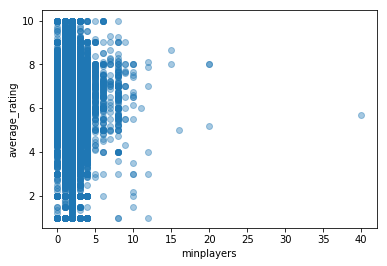

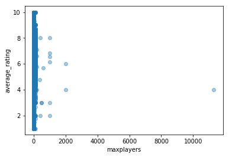

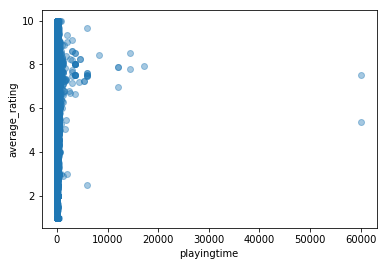

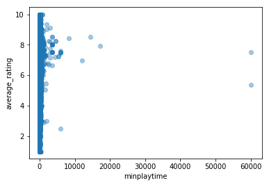

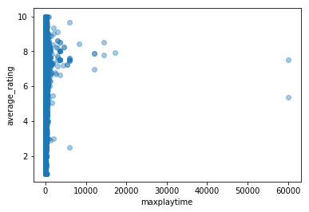

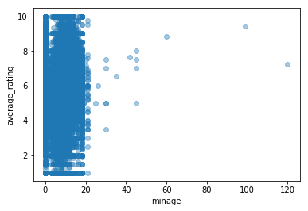

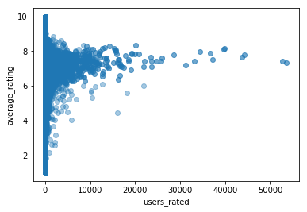

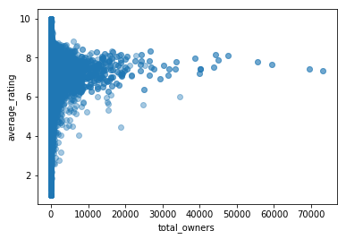

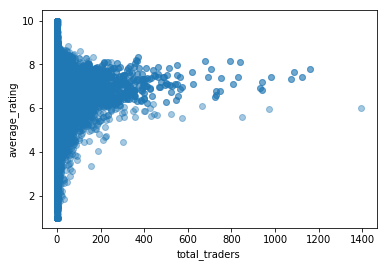

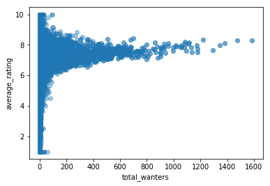

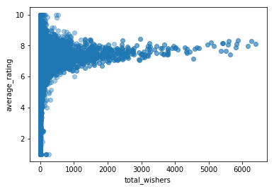

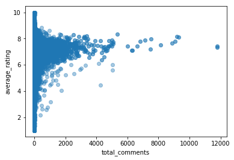

[2 more figures not shown]

```python
# Plotting scatter plots between
for c in columns:
    plt.scatter(game[c],game[target], alpha = 0.4)
    plt.xlabel(c)
    plt.ylabel(target)
    plt.show()
```

Judging from the previous plots, following observations and changes could be made in the future if there is any improvement to be made to the model:

1. most do not correlate linearly
2. the values could be scaled such that each feature is in proper scale (Consider this as a potential improvement for the future)

# 3. Data Preparation and Model Training

```python
# Splitting the above obtained arrays into testing and training arrays

X_train, X_test, Y_train, Y_test = train_test_split(X_Var, Y_tar, test_size = 0.2, random_state = 53)

print(X_train.shape)
print(X_test.shape)
print(Y_train.shape)
print(Y_test.shape)
```

```
(45515, 14)
(11379, 14)
(45515,)
(11379,)
```

Thus, the test and training datasets were chosen using the train_test_split method and the models would be trained and evaluated using these data sets.

```python
from sklearn.linear_model import LinearRegression
from sklearn.metrics import mean_squared_error
from sklearn.ensemble import RandomForestRegressor

LR = LinearRegression()
RFR = RandomForestRegressor(n_estimators = 100, min_samples_leaf = 10, random_state = 1)

LR.fit(X_train,Y_train)
LR_prediction = LR.predict(X_test)
mse_LR = mean_squared_error(LR_prediction, Y_test)

RFR.fit(X_train,Y_train)
RFR_prediction = RFR.predict(X_test)
mse_RFR = mean_squared_error(RFR_prediction, Y_test)

print('Mean Square Error for Linear Regression Model is {}', mse_LR)
print('Mean Square Error for Linear Regression Model is {}', mse_RFR)
```

```
Mean Square Error for Linear Regression Model is {} 2.1088236681874415
Mean Square Error for Linear Regression Model is {} 1.5791483794644599
```